# Análise Exploratória imdb

Ivan Ormenesse

23/8/2020

### Entendendo um pouco dos dados e do mercado de cinema

Para iniciar vamos dar uma olhada em uma base ordenada por nota do imdb, likes no facebook e lucro. Talvez esta primeira análise nos dê ideias sobre os próximos passos da análise e sobre como ajudar o Athos e o Fernando a investirem no incrível mundo do cinema:

20 filmes ordenados em temos de nota do imdb, likes do facebook e lucro (nesta ordem)

| diretor | ano | cor | nota_imdb | likes_facebook | lucro |
| --- | --- | --- | --- | --- | --- |
| Christopher Nolan | 2008 | Color | 9.0 | 37000 | 348316061 |
| Peter Jackson | 2003 | Color | 8.9 | 16000 | 283019252 |
| Robert Zemeckis | 1994 | Black and White | 8.8 | 59000 | 274691196 |
| George Lucas | 1977 | Color | 8.7 | 33000 | 449935665 |
| Roger Allers | 1994 | Color | 8.5 | 17000 | 377783777 |
| Richard Marquand | 1983 | Color | 8.4 | 14000 | 276625409 |
| Andrew Stanton | 2003 | Color | 8.2 | 11000 | 286838870 |
| Joss Whedon | 2012 | Color | 8.1 | 123000 | 403279547 |
| Steven Spielberg | 1993 | Color | 8.1 | 19000 | 293784000 |
| Tim Miller | 2016 | Color | 8.1 | 117000 | 305024263 |
| James Cameron | 2009 | Color | 7.9 | 33000 | 523505847 |
| Steven Spielberg | 1982 | Color | 7.9 | 34000 | 424449459 |
| James Cameron | 1997 | Color | 7.7 | 26000 | 458672302 |
| Francis Lawrence | 2013 | Color | 7.6 | 82000 | 294645577 |
| Pierre Coffin | 2013 | Color | 7.5 | 56000 | 292049635 |
| Gary Ross | 2012 | Color | 7.3 | 140000 | 329999255 |
| Clint Eastwood | 2014 | Color | 7.3 | 112000 | 291323553 |
| Andrew Adamson | 2004 | Color | 7.2 | 0 | 286471036 |
| Colin Trevorrow | 2015 | Color | 7.0 | 150000 | 502177271 |
| George Lucas | 1999 | Color | 6.5 | 13000 | 359544677 |

Considerando que a base contem filmes até 2016 podemos notar que esta análise bastante preliminar indica uma predominância de filme realizados nos últimos 20 anos e em cores. Portanto, vamos dar uma olhada na relação entre filmes em cores nota do imdb, like do facebook e lucro:

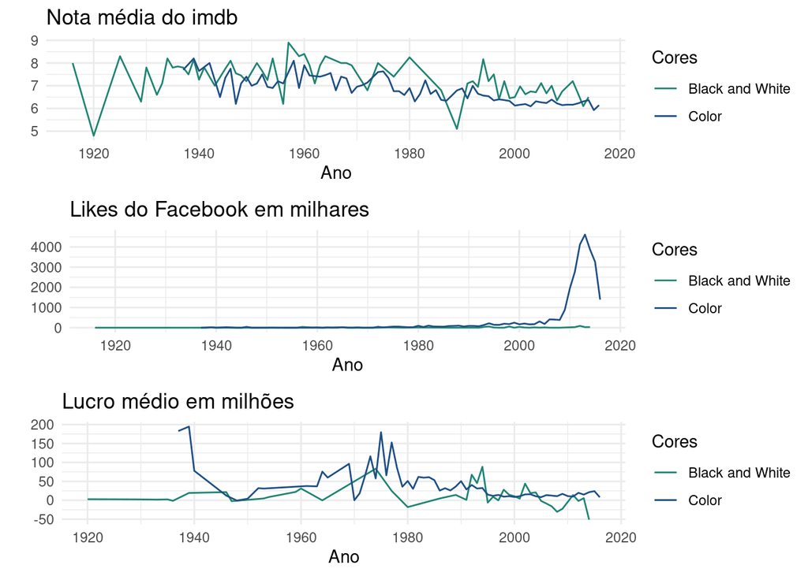

Enquanto as notas do imdb e o lucro são relativamente similares para filmes em cores e em preto e branco, o comportamento dos likes no facebook indica uma maior representatividade de filmes recentes. Com base nisso vamos analisar outras variáveis que possam ser determinantes para o sucesso do filme.

### Analisando os gêneros

Vamos olhar para genero, atores e diretores para nota do imdb:

[figure not shown]

Em termos de gênero, Film-noir parece ser o melhor avaliado pelos críticos, Sci-Fi pelo público que usa o Facebook e Animações são os filmes que mais produzem Lucro. No entanto, podemos aproveitar as informações para gerar insumos para um roteiro de sucesso. Poderíamos propor uma animação de aventura e sci-fi focada no público familiar. A nota do imdb parece ser mais focada na avaliação da crítica especializada, por isso não vamos direcionar a seleção de gênero por isso.

Os dados também indicam uma tendência de crescimento na quantidade de filmes destes 3 gêneros à partir do ano de 1980, com destaque para Aventura e Sci-fi, que cresceram mais do que as animações.

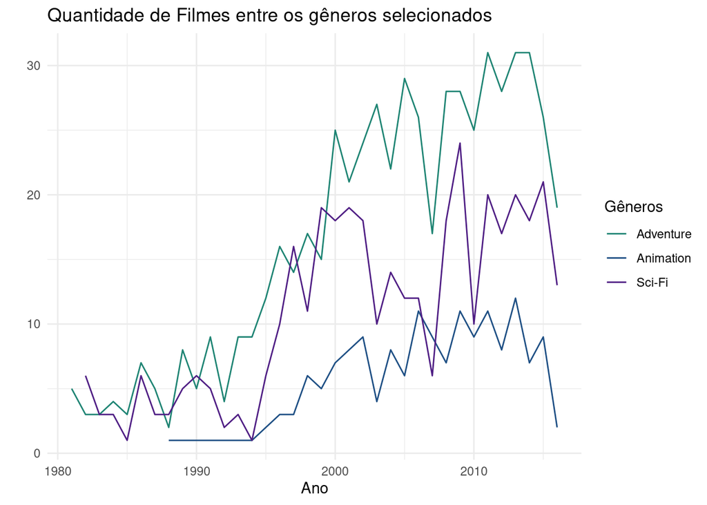

**Com estas informações e mão, vamos selecionar nossos atores, para isto, vamos filtrar os melhores dos gêneros selecionados: Animation, Adventure e Sci-Fi.**

### Analisando quem serão as estrelas do filme

Vamos entender quem são os principais nomes em termos de atores e diretores para o tipo de filme que pretendemos produzir. Naturalmente, gostaríamos de ter algum profissionais com experiência.

Nossa base contem **953 filmes de um dos 3 generos selecionados**, vamos entender a quantidade de vezes que cada ator trabalhou em filmes deste tipo:

20 atores ordenados em temos de quantidade de filmes, lucro, nota do imdb e likes do Facebook

| atores | qtd_filmes | lucro_medio | nota_imdb | likes_facebook |
| --- | --- | --- | --- | --- |
| Harrison Ford | 13 | 137.532522 | 7.492308 | 22.92308 |
| Johnny Depp | 13 | 29.532818 | 6.838462 | 23.61538 |
| Bruce Willis | 12 | 16.821678 | 6.866667 | 22.08333 |
| Steve Buscemi | 12 | 18.402300 | 6.658333 | 10.48183 |
| Bill Murray | 11 | 15.602379 | 6.854546 | 23.79955 |
| Hugh Jackman | 11 | 4.205599 | 7.109091 | 34.00000 |
| Chris Hemsworth | 10 | 65.976252 | 6.950000 | 51.40000 |
| J.K. Simmons | 10 | 46.120995 | 6.730000 | 12.68620 |
| John Ratzenberger | 10 | 114.486111 | 7.890000 | 12.20000 |
| Josh Hutcherson | 10 | 104.956217 | 6.570000 | 33.50000 |
| Sylvester Stallone | 10 | 6.388529 | 6.100000 | 25.76810 |
| Angelina Jolie Pitt | 9 | 18.922490 | 6.544444 | 15.44444 |
| Dwayne Johnson | 9 | 20.505523 | 6.044444 | 12.77778 |
| Robert Downey Jr. | 9 | 160.716385 | 7.566667 | 55.00000 |
| Scarlett Johansson | 9 | 105.791918 | 7.666667 | 64.77778 |
| Tom Cruise | 9 | 32.803004 | 7.055556 | 20.33333 |
| Will Smith | 9 | 43.027509 | 6.444444 | 20.66667 |
| Christian Bale | 8 | 4.831946 | 7.350000 | 10.50000 |
| Gary Oldman | 8 | 3.061907 | 6.562500 | 18.12500 |
| Gerard Butler | 8 | -18.722960 | 6.337500 | 12.87500 |

Estes são os principais nomes no meio, vamos ver fazer um gráfico de barras para tomarmos uma descisão:

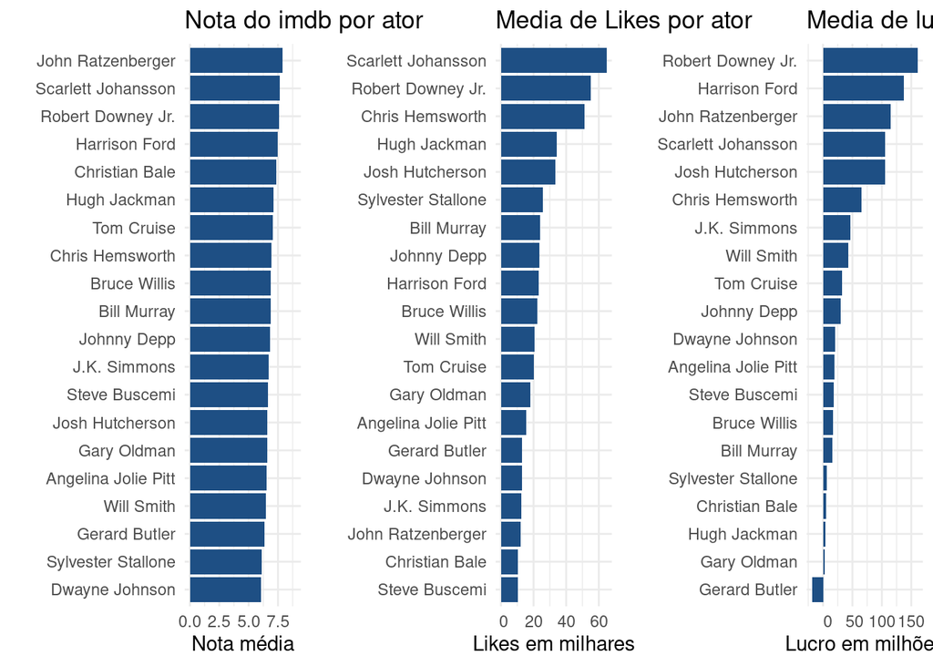

O nosso filme poderia contar com as participações de John Ratzenberger, Scarlett Johansson, Robert Downey Jr. e Harrison Ford. Josh Hutcherson aparece em filmes com muitos likes e muito lucrativos, já Christian Bale e Hugh Jackman são aclamados pela crítica do imdb. Mas, pensando em dinheiro nossa escalação seria: * Robert Downey Jr * Harrison Ford * John Ratzenberger * Scarlett Johansson * Josh Hutcherson

### Escolhendo um diretor

Agora precisamos escolher nosso diretor. Vamos seguir a mesma abordagem, mas vamos ser um pouco mais cautelos, pois, neste caso, precisamos de um líder consistente para o nosso filme.

[figure not shown]

Difícil escolha, entre os generos que estamos analisando temos 3 diretores que se saem muito bem. Brad Bird, para imdb, Ridley Scott no facebook, e Steven Spilberg em termos de lucro.

Como estamos em um mundo capitalista, o lucro sempre se sobressai, mas precisamos ter certeza de que nossa decisão não será tomada com base em algum evento passado ou atípico na carreira de algum desses diretores. Vamos avaliar sua consistência:

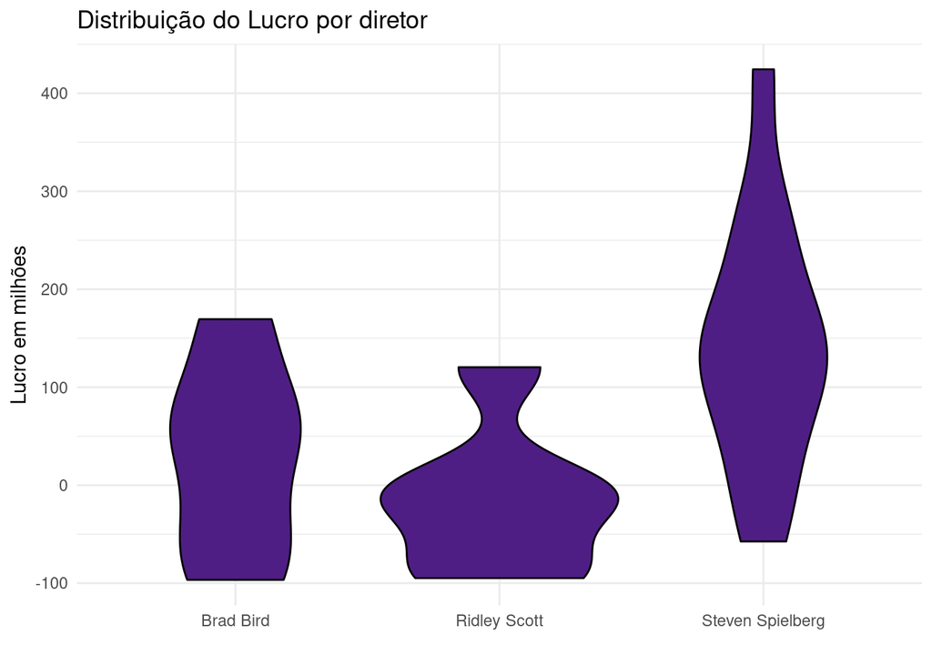

### Conclusões

A análise nos leva a concluir que o mais lógico a se fazer seria investir em uma produção com algum dos seguintes gêneros:

- Animação
- Aventura
- Ficção Científica

Com a participação dos seguintes atores:

- Robert Downey Jr
- Harrison Ford
- John Ratzenberger
- Scarlett Johansson
- Josh Hutcherson

E que fosse dirigida por ninguém mais ninguém menos que:

**Steven Spielberg**